# 11 - Neural Networks

Biostatistics 735/794 — Machine Learning in Public Health

Alexander McLain

October 20, 2025

```r
knitr::opts_chunk$set(
  echo = TRUE,
  message = FALSE,
  warning = FALSE,
  cache = TRUE,
  fig.width = 7,
  fig.height = 4.5
)
library(tidyverse)
library(kableExtra)
library(printr)
library(mlbench)
library(neuralnet)
library(tensorflow)
library(keras)
library(reticulate)
library(clusterGeneration)
library(nnet)
library(devtools)
library(reshape)
library(caret)
library(randomForest)
kbl2 <- function(x, ...) kable(x, align = "lrrrrrr", ...) %>% kable_styling(full_width = FALSE)
```

Our example data set is from the Wisconsin cancer study. We read in the data and remove any rows with missing data. The following code uses the package `mlbench` that contains this data set. We show the top few lines of the data.

```r
data("BreastCancer")

#Clean off rows with missing data
BreastCancer = BreastCancer[which(complete.cases(BreastCancer)==TRUE),]
dim(BreastCancer)
```

```
## [1] 683  11
```

```r
head(BreastCancer)
```

| Id | Cl.thickness | Cell.size | Cell.shape | Marg.adhesion | Epith.c.size | Bare.nuclei | Bl.cromatin | Normal.nucleoli | Mitoses | Class |
| --- | --- | --- | --- | --- | --- | --- | --- | --- | --- | --- |
| 1000025 | 5 | 1 | 1 | 1 | 2 | 1 | 3 | 1 | 1 | benign |
| 1002945 | 5 | 4 | 4 | 5 | 7 | 10 | 3 | 2 | 1 | benign |
| 1015425 | 3 | 1 | 1 | 1 | 2 | 2 | 3 | 1 | 1 | benign |
| 1016277 | 6 | 8 | 8 | 1 | 3 | 4 | 3 | 7 | 1 | benign |
| 1017023 | 4 | 1 | 1 | 3 | 2 | 1 | 3 | 1 | 1 | benign |
| 1017122 | 8 | 10 | 10 | 8 | 7 | 10 | 9 | 7 | 1 | malignant |

```r
?BreastCancer
```

| BreastCancer | R Documentation |
| --- | --- |

## Wisconsin Breast Cancer Database

### Description

The objective is to identify each of a number of benign or malignant classes. Samples arrive periodically as Dr. Wolberg reports his clinical cases. The database therefore reflects this chronological grouping of the data. This grouping information appears immediately below, having been removed from the data itself. Each variable except for the first was converted into 11 primitive numerical attributes with values ranging from 0 through 10. There are 16 missing attribute values. See cited below for more details.

### Format

A data frame with 699 observations on 11 variables, one being a character variable, 9 being ordered or nominal, and 1 target class.

| [,1] | Id | Sample code number |
| --- | --- | --- |
| [,2] | Cl.thickness | Clump Thickness |
| [,3] | Cell.size | Uniformity of Cell Size |
| [,4] | Cell.shape | Uniformity of Cell Shape |
| [,5] | Marg.adhesion | Marginal Adhesion |
| [,6] | Epith.c.size | Single Epithelial Cell Size |
| [,7] | Bare.nuclei | Bare Nuclei |
| [,8] | Bl.cromatin | Bland Chromatin |
| [,9] | Normal.nucleoli | Normal Nucleoli |
| [,10] | Mitoses | Mitoses |
| [,11] | Class | Class |

```r
str(BreastCancer)
```

```
## 'data.frame':    683 obs. of  11 variables:
##  $ Id             : chr  "1000025" "1002945" "1015425" "1016277" ...
##  $ Cl.thickness   : Ord.factor w/ 10 levels "1"<"2"<"3"<"4"<..: 5 5 3 6 4 8 1 2 2 4 ...
##  $ Cell.size      : Ord.factor w/ 10 levels "1"<"2"<"3"<"4"<..: 1 4 1 8 1 10 1 1 1 2 ...
##  $ Cell.shape     : Ord.factor w/ 10 levels "1"<"2"<"3"<"4"<..: 1 4 1 8 1 10 1 2 1 1 ...
##  $ Marg.adhesion  : Ord.factor w/ 10 levels "1"<"2"<"3"<"4"<..: 1 5 1 1 3 8 1 1 1 1 ...
##  $ Epith.c.size   : Ord.factor w/ 10 levels "1"<"2"<"3"<"4"<..: 2 7 2 3 2 7 2 2 2 2 ...
##  $ Bare.nuclei    : Factor w/ 10 levels "1","2","3","4",..: 1 10 2 4 1 10 10 1 1 1 ...
##  $ Bl.cromatin    : Factor w/ 10 levels "1","2","3","4",..: 3 3 3 3 3 9 3 3 1 2 ...
##  $ Normal.nucleoli: Factor w/ 10 levels "1","2","3","4",..: 1 2 1 7 1 7 1 1 1 1 ...
##  $ Mitoses        : Factor w/ 9 levels "1","2","3","4",..: 1 1 1 1 1 1 1 1 5 1 ...
##  $ Class          : Factor w/ 2 levels "benign","malignant": 1 1 1 1 1 2 1 1 1 1 ...
```

Since `neuralnet` only deals with quantitative variables, you can convert all the qualitative variables (factors) to binary (“dummy”), with the `model.matrix` function.

```r
y = as.matrix(BreastCancer[,11])
y[which(y=="benign")] = 0
y[which(y=="malignant")] = 1
y = as.numeric(y)
x = model.matrix(~0 + Cl.thickness + Cell.size + Cell.shape +
                         Marg.adhesion + Epith.c.size + Bare.nuclei + Bl.cromatin +
                         Normal.nucleoli + Mitoses, data = BreastCancer)
dim(x)
```

```
## [1] 683  81
```

```r
df <- data.frame(y,x)
```

Let’s split the data into training and validation:

```r
set.seed(92739847)
ids <- sample(1:dim(df)[1],size=dim(df)[1])
df_jumbled <- df[ids,]
train <- df_jumbled[1:450,]
test <- df_jumbled[451:nrow(df_jumbled),]

# Normalize predictors (always important for NN)
x_mn <- apply(train[-y],2,mean)
x_sd <- apply(train[-y],2,sd)
train[-y] <- scale(train[-y])
test[-y] <- scale(test[-y], center = x_mn,
                          scale = x_sd)
```

# Fitting with `neuralnet`

In the first example, we will create a simple neural network with minimum effort using the `neuralnet` package. The `neuralnet` package is outdated, but it is still popular among the R community.

The `neuralnet` function is simple. It doesn’t provide us the freedom to create fully customizable model architecture.In our case, we are providing it with a machine-learning formula and data, just like GLM. The formula consists of target variables and features.

```r
?neuralnet
```

| neuralnet | R Documentation |
| --- | --- |

## Training of neural networks

### Description

Train neural networks using backpropagation, resilient backpropagation (RPROP) with (Riedmiller, 1994) or without weight backtracking (Riedmiller and Braun, 1993) or the modified globally convergent version (GRPROP) by Anastasiadis et al. (2005). The function allows flexible settings through custom-choice of error and activation function. Furthermore, the calculation of generalized weights (Intrator O. and Intrator N., 1993) is implemented.

### Usage

```r
neuralnet(formula, data, hidden = 1, threshold = 0.01,
  stepmax = 1e+05, rep = 1, startweights = NULL,
  learningrate.limit = NULL, learningrate.factor = list(minus = 0.5,
  plus = 1.2), learningrate = NULL, lifesign = "none",
  lifesign.step = 1000, algorithm = "rprop+", err.fct = "sse",
  act.fct = "logistic", linear.output = TRUE, exclude = NULL,
  constant.weights = NULL, likelihood = FALSE)
```

### Arguments

| `formula` | a symbolic description of the model to be fitted. |
| --- | --- |
| `data` | a data frame containing the variables specified in `formula`. |
| `hidden` | a vector of integers specifying the number of hidden neurons (vertices) in each layer. |
| `threshold` | a numeric value specifying the threshold for the partial derivatives of the error function as stopping criteria. |
| `stepmax` | the maximum steps for the training of the neural network. Reaching this maximum leads to a stop of the neural network's training process. |
| `rep` | the number of repetitions for the neural network's training. |
| `startweights` | a vector containing starting values for the weights. Set to `NULL` for random initialization. |
| `learningrate.limit` | a vector or a list containing the lowest and highest limit for the learning rate. Used only for RPROP and GRPROP. |
| `learningrate.factor` | a vector or a list containing the multiplication factors for the upper and lower learning rate. Used only for RPROP and GRPROP. |
| `learningrate` | a numeric value specifying the learning rate used by traditional backpropagation. Used only for traditional backpropagation. |
| `lifesign` | a string specifying how much the function will print during the calculation of the neural network. 'none', 'minimal' or 'full'. |
| `lifesign.step` | an integer specifying the stepsize to print the minimal threshold in full lifesign mode. |
| `algorithm` | a string containing the algorithm type to calculate the neural network. The following types are possible: 'backprop', 'rprop+', 'rprop-', 'sag', or 'slr'. 'backprop' refers to backpropagation, 'rprop+… |
| `err.fct` | a differentiable function that is used for the calculation of the error. Alternatively, the strings 'sse' and 'ce' which stand for the sum of squared errors and the cross-entropy can be used. |
| `act.fct` | a differentiable function that is used for smoothing the result of the cross product of the covariate or neurons and the weights. Additionally the strings, 'logistic' and 'tanh' are possible for the l… |
| `linear.output` | logical. If act.fct should not be applied to the output neurons set linear output to TRUE, otherwise to FALSE. |
| `exclude` | a vector or a matrix specifying the weights, that are excluded from the calculation. If given as a vector, the exact positions of the weights must be known. A matrix with n-rows and 3 columns will exc… |
| `constant.weights` | a vector specifying the values of the weights that are excluded from the training process and treated as fix. |
| `likelihood` | logical. If the error function is equal to the negative log-likelihood function, the information criteria AIC and BIC will be calculated. Furthermore the usage of confidence.interval is meaningfull. |

### Details

The globally convergent algorithm is based on the resilient backpropagation without weight backtracking and additionally modifies one learning rate, either the learningrate associated with the smallest absolute gradient (sag) or the smallest learningrate (slr) itself. The learning rates in the grprop algorithm are limited to the boundaries defined in learningrate.limit.

## Choosing the Number of Hidden Layers and Neurons

The number of hidden layers and neurons per layer determine a neural network’s capacity — its ability to represent complex patterns in the data. Too little capacity leads to underfitting; too much leads to overfitting.

**Number of Hidden Layers**

• Start simple: Most problems are captured with 1–2 hidden layers.

• A single hidden layer can approximate any smooth function (the universal approximation theorem).

• Two layers can often capture hierarchical or compositional patterns (e.g., interactions, nonlinear thresholds). • Add layers only if justified:

```
-   You have very large data (tens of thousands of observations).
-   You’re working with structured complexity, such as images, sequences, or text.
-   Performance clearly improves (based on validation error) when adding layers.
```

**Number of Neurons per Layer**

• *Rule of thumb:* Start with a size between the number of input features and the number of output classes. Example: if you have 20 predictors and 2 outcomes, try 10–20 neurons in the first layer.

• Too few neurons → underfit: Model can’t capture the data’s patterns.

• Too many neurons → overfit: Model memorizes noise. Regularization (dropout, weight decay) helps, but doesn’t replace tuning.

• Common heuristic:

$$neurons \ per \ layer =
\frac{n_{samples}}{\alpha(n_{features} + n_{outputs})}$$

with $\alpha$ between 2–10 as a complexity control factor.

These rules come from early neural network literature (1980s–1990s). A quaint time when people ran mostly shallow, one-hidden-layer networks trained on small datasets using **simple gradient descent** and **no regularization**.

Those rules of thumb were designed to:

• Avoid overfitting when no dropout or weight decay existed,

• Constrain computational cost,

• Fit networks by hand-tuning on small CPUs.

They were useful back when having hundreds of parameters was “big.”

**Practical Tuning Strategy**

1. Begin with 1 hidden layer and vary neuron counts (e.g., 4, 8, 16, 32).
2. Use cross-validation to choose the architecture with the best validation accuracy or lowest validation loss.
3. Add a second hidden layer only if performance plateaus.
4. Always watch the training vs. validation loss curves — divergence signals overfitting.

In this example, we’ll fit a relatively simple NN with 450 observations, 81 features and 1 output layer. With $\alpha = 2$ this gives

$$neurons \ per \ layer = \frac{450}{2(81
+ 1)} = 2.7$$

```r
Breast_NN <- neuralnet(y ~ ., data = train,
                      hidden = 4, lifesign = "minimal", algorithm="backprop",
                      linear.output = FALSE, err.fct = 'ce',
                      learningrate=0.1)

# Look at the error and activation function
Breast_NN$err.fct
```

```
## function (x, y)
## {
##     -(y * log(x) + (1 - y) * log(1 - x))
## }
## <bytecode: 0xc8c623348>
## <environment: 0xc8c62de70>
## attr(,"type")
## [1] "ce"
```

```r
Breast_NN$act.fct
```

```
## function (x)
## {
##     1/(1 + exp(-x))
## }
## <bytecode: 0xc8c60f000>
## <environment: 0xc8c60e708>
## attr(,"type")
## [1] "logistic"
```

```r
# Here are the parameters:
dim(Breast_NN$result.matrix)
```

```
## [1] 336   1
```

```r
253/81
```

```
## [1] 3.123457
```

```r
head(data.frame(Breast_NN$result.matrix))
```

|  | Breast_NN.result.matrix |
| --- | --- |
| error | 28.0575087 |
| reached.threshold | 0.0099566 |
| steps | 2718.0000000 |
| Intercept.to.1layhid1 | 1.9970657 |
| Cl.thickness1.to.1layhid1 | 1.9092348 |
| Cl.thickness2.to.1layhid1 | 0.7112792 |

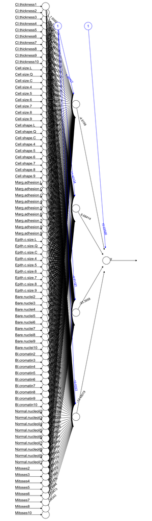

```r
plot(Breast_NN, rep="best")
```

```r
valid_pred <- predict(Breast_NN, newdata = test)
table(valid_pred>0.5, test$y)
```

| / | 0 | 1 |
| --- | --- | --- |
| FALSE | 147 | 4 |
| TRUE | 6 | 76 |

```r
# Accuracy
sum(diag(table(valid_pred>0.5, test$y)))/length(test$y)
```

```
## [1] 0.9570815
```

# Fitting with `TensorFlow`

`TensorFlow` is an open source deep neural net framework, based on a graphical model. It is more than just a neural net platform, and supports numerical computing based on data flow graphs. Data may be represented in $n$-dimensional structures like vectors and matrices, or higher-dimensional tensors. Because these mathematical objects are folded into a data flow graph for computation, the moniker for this software library is an obvious one.

The computations for deep learning nets involve tensor computations, which are known to be implemented more efficiently on GPUs than CPUs. Therefore like other deep learning libraries, `TensorFlow` may be implemented on CPUs and GPUs. The generality and speed of the `TensorFlow` software, ease of installation, its documentation and examples, and runnability on multiple platforms has made `TensorFlow` the most popular deep learning toolkit today. (Opinions on this may, of course, differ.) There is a wealth of tutorial material on TF of very high quality that you may refer to here: https://www.tensorflow.org/tutorials/.

Rather than run `TensorFlow` natively, it is often easier to use it through an easy to use interface program. One of the most popular high-level APIs is `Keras` See: https://keras.io/. The site contains several examples, which make it easy to get up and running. Though originally written in Python, `Keras` has been extended to `R` via the `keras` package.

`Keras` is a high-level neural networks API developed with a focus on enabling fast experimentation. Being able to go from idea to result with the least possible delay is key to doing good research. Keras has the following key features:

- Allows the same code to run on CPU or on GPU, seamlessly.
- User-friendly API which makes it easy to quickly prototype deep learning models.
- Built-in support for convolutional networks (for computer vision), recurrent networks (for sequence processing), and any combination of both.
- Supports arbitrary network architectures: multi-input or multi-output models, layer sharing, model sharing, etc. This means that Keras is appropriate for building essentially any deep learning model, from a memory network to a neural Turing machine.

To use these functions were going to convert the outcome (benign, malignant) in the data set to “one-hot encoding” using the to_categorial function. What is one-hot encoding replaces a single vector of 1s (malignant) and 0s (benign) to a bivariate dependent variable as a two-column matrix, where the first column contains a 1 if the cell is benign and the second column a 1 if the cell is malignant, for each row of the data set. This is because TensorFlow/Keras requires this format as input, to facilitate tensor calculations.

```r
y_train = as.vector(train[,1])
y_test = as.vector(test[,1])
x_train = as.matrix(train[,-1])
x_test = as.matrix(test[,-1])

Y_train = to_categorical(y_train, 2)
Y_test = to_categorical(y_test,2)
```

`TensorFlow` is structured in a manner where one describes the neural net first, layer by layer. We first describe, for each layer in the neural net, **the number of nodes, the type of activation function, and any other hyperparameters needed in the model fitting stage, such as the extent of dropout for example.**

In the output layer, we also state the nature of the activation function, such as sigmoid or softmax. And then, we specify a `compile` function which describes the loss function that will be minimized, along with the minimization algorithm. **At this point in the program specification, the model is not actually run.** See below for the `history` code block that builds up the deep learning network.

The core data structure of Keras is a model and a way to organize layers. The simplest type of model is the *Sequential model*, a linear stack of layers.

We begin by creating a sequential model and then adding layers using the pipe (`%>%`) operator:

```r
?keras_model_sequential
```

| keras_model_sequential | R Documentation |
| --- | --- |

## Keras Model composed of a linear stack of layers

### Description

Keras Model composed of a linear stack of layers

### Usage

```r
keras_model_sequential(layers = NULL, name = NULL, ...)
```

### Arguments

| `layers` | List of layers to add to the model |
| --- | --- |
| `name` | Name of model |
| `...` | Arguments passed on to `sequential_model_input_layer` **`input_shape`** an integer vector of dimensions (not including the batch axis), or a `tf$TensorShape` instance (also not including the batch axi… |

Build Model

```r
n_features <- ncol(x_train)

model <- keras_model_sequential() %>%
  layer_dense(units = 128, activation = "relu", input_shape = c(n_features)) %>%
  layer_dropout(rate = 0.3) %>%
  layer_dense(units = 64, activation = "relu") %>%
  layer_dropout(rate = 0.25) %>%
  layer_dense(units = 32, activation = "relu") %>%
  layer_dropout(rate = 0.2) %>%
  layer_dense(units = 2, activation = "softmax")

summary(model)
```

```
## Model: "sequential"
## ________________________________________________________________________________
##  Layer (type)                       Output Shape                    Param #
## ================================================================================
##  dense_3 (Dense)                    (None, 128)                     10496
##  dropout_2 (Dropout)                (None, 128)                     0
##  dense_2 (Dense)                    (None, 64)                      8256
##  dropout_1 (Dropout)                (None, 64)                      0
##  dense_1 (Dense)                    (None, 32)                      2080
##  dropout (Dropout)                  (None, 32)                      0
##  dense (Dense)                      (None, 2)                       66
## ================================================================================
## Total params: 20898 (81.63 KB)
## Trainable params: 20898 (81.63 KB)
## Non-trainable params: 0 (0.00 Byte)
## ________________________________________________________________________________
```

## Why so many nuerons?!?

Note that we are using a much larger number of parameters than the **rules of thumb** given above. That’s because we are leveraging **overparameterization + regularization** — a very different regime.

Here’s why more neurons can be better, even with modest sample sizes:

• **Representation capacity:** Nonlinear relationships, feature interactions, and subtle variable dependencies often require many hidden units to represent accurately. Having more neurons gives the model the capacity to find those patterns.

• **Regularization keeps it in check:** Dropout, L2 weight penalties, and early stopping (tuning the number of epochs) all prevent the network from memorizing noise. So you can afford a larger model without necessarily overfitting.

• **Optimization stability:** Wider layers create smoother loss landscapes and make training more stable — gradients propagate better, especially with ReLU activations.

• **Empirical tuning, not analytical derivation:** Modern practice doesn’t rely on formulas; it relies on validation-based tuning (or automated hyperparameter search). In practice, “128–64–32” is just a safe mid-sized starting point for tabular data with a few hundred features.

Even though we have 450 observations, 81 features, many of which are correlated but nonlinear (e.g., textural measures of nuclei), a 3-layer network with decreasing widths (128 → 64 → 32) is:

• expressive enough to capture nonlinear feature combinations,

• computationally cheap (only ~15k–20k trainable weights).

If you used only 2–3 neurons, the model would collapse into a nearly linear function — equivalent to a logistic regression.

Compile Model

```r
model %>% compile(
  optimizer = optimizer_adam(learning_rate = 0.001),
  loss = "categorical_crossentropy",
  metrics = c("accuracy")
)
```

From this I got the following message:

WARNING:absl:At this time, the v2.11+ optimizer `tf.keras.optimizers.RMSprop` runs slowly on M1/M2 Macs, please use the legacy Keras optimizer instead, located at `tf.keras.optimizers.legacy.RMSprop`.

```r
model %>% compile(
  loss = 'categorical_crossentropy',
  metrics = c('accuracy')
)
```

Fit Model

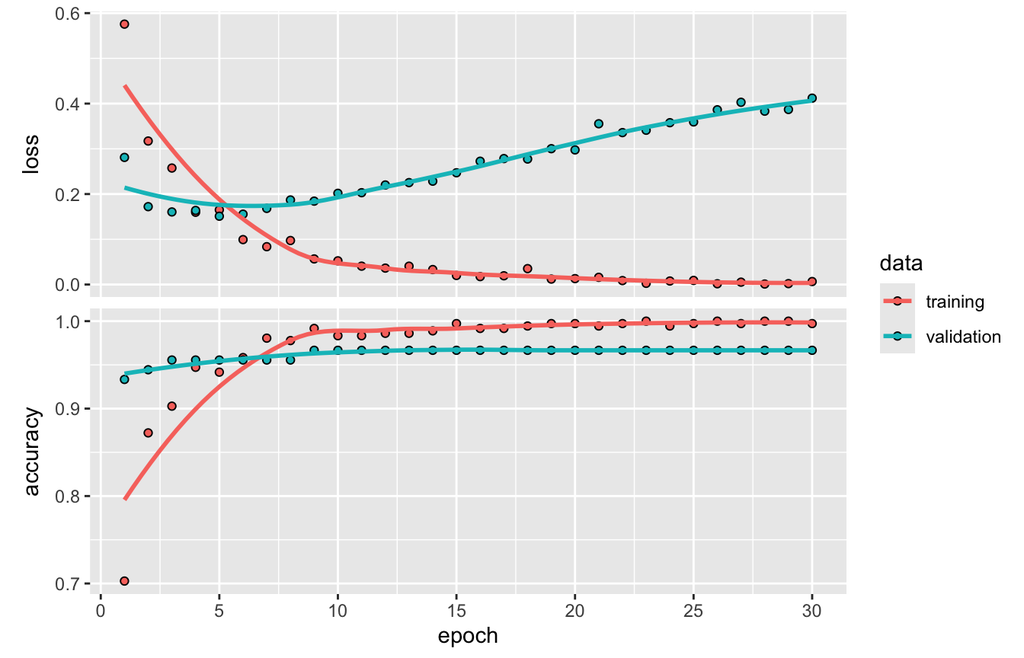

```r
history <- model %>% fit(
  x = x_train,
  y = Y_train,
  epochs = 30,
  batch_size = 32,
  validation_split = 0.2,
  verbose = 1
)
# Optional: plot training progress
plot(history)
```

Evaluate on Test Data

```r
score <- model %>% evaluate(x_test, Y_test, verbose = 0)
cat("Test Accuracy:", round(score["accuracy"], 3), "\n")
```

```
## Test Accuracy: 0.979
```

```r
# ----------------------------------------------------------
# Predict
# ----------------------------------------------------------
pred_prob <- model %>% predict(x_test)
```

```
## 8/8 - 0s - 136ms/epoch - 17ms/step
```

```r
pred_class <- apply(pred_prob, 1, which.max) - 1  # 0/1 classes

# ----------------------------------------------------------
# Compute evaluation metrics
# ----------------------------------------------------------
results <- tibble(
  truth = factor(y_test, levels = c(0, 1)),
  .pred_0 = pred_prob[,1],
  .pred_1 = pred_prob[,2],
  .pred_class = factor(pred_class, levels = c(0, 1))
) |>
  mutate(
    truth = factor(truth, levels = c(0, 1)),
    .pred_class = factor(.pred_class, levels = c(0, 1))
  )

# Call each metric explicitly and specify event_level = "second"
metrics_summary <- yardstick::metric_set(
  yardstick::roc_auc,
  yardstick::accuracy,
  yardstick::sensitivity,
  yardstick::specificity,
  yardstick::ppv,
  yardstick::npv
)

NN_summary <- metrics_summary(
  data = results,
  truth = truth,
  estimate = .pred_class,
  estimator = "binary",
  event_level = "second",
  .pred_1
) %>% dplyr::select(.metric,.estimate) %>%
  dplyr::rename(
    Metric = .metric,
    Estimate = .estimate
  )
NN_summary %>% kbl2(digits = 3)
```

| Metric | Estimate |
| --- | --- |
| accuracy | 0.979 |
| sensitivity | 0.975 |
| specificity | 0.980 |
| ppv | 0.963 |
| npv | 0.987 |
| roc_auc | 0.997 |

# Compare with Random Forests

```r
# Define training control for 10-fold CV
ctrl <- trainControl(method = "cv", number = 10,
                     classProbs = TRUE,
                     summaryFunction = twoClassSummary)

train_rf <- train %>%
  mutate(
    y = case_when(
      y == 0 ~"benign",
      TRUE ~ "malignant")
  )

test_rf <- test %>%
  mutate(
    y = case_when(
      y == 0 ~"benign",
      TRUE ~ "malignant")
  )


# Train random forest model with CV to tune mtry
rf_caret <- train(y ~ .,
                  data = train_rf,
                  method = "rf",
                  metric = "ROC",   # use AUC as performance measure
                  trControl = ctrl,
                  tuneGrid = data.frame(mtry = 1:10)) # grid of mtry values

rf_caret
```

```
## Random Forest
##
## 450 samples
##  81 predictor
##   2 classes: 'benign', 'malignant'
##
## No pre-processing
## Resampling: Cross-Validated (10 fold)
## Summary of sample sizes: 405, 405, 405, 405, 405, 405, ...
## Resampling results across tuning parameters:
##
##   mtry  ROC        Sens       Spec
##    1    0.9886585  0.9622989  0.9308333
##    2    0.9877965  0.9554023  0.9308333
##    3    0.9875776  0.9588506  0.9245833
##    4    0.9868199  0.9519540  0.9245833
##    5    0.9853113  0.9519540  0.9245833
##    6    0.9873587  0.9485057  0.9245833
##    7    0.9862744  0.9519540  0.9245833
##    8    0.9868132  0.9519540  0.9245833
##    9    0.9859444  0.9485057  0.9245833
##   10    0.9859511  0.9519540  0.9245833
##
## ROC was used to select the optimal model using the largest value.
## The final value used for the model was mtry = 1.
```

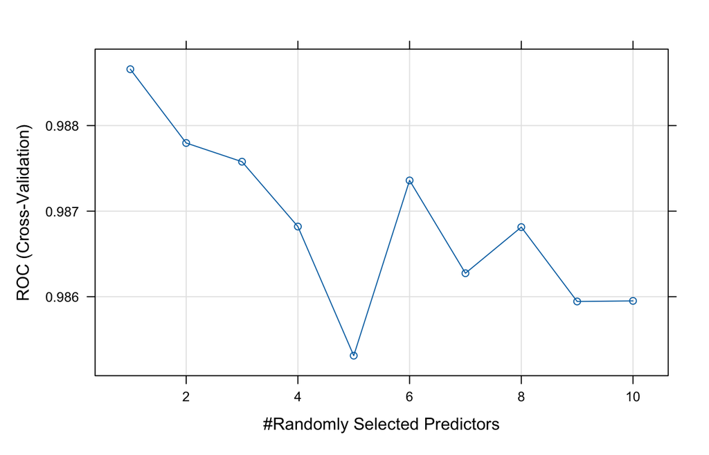

```r
plot(rf_caret)
```

```r
pred_prob_rf <- predict(rf_caret$finalModel, newdata = test, type =  "prob")
pred_class_rf <- apply(pred_prob_rf, 1, which.max) - 1  # 0/1 classes

pred_class_rf[which(pred_class_rf==0)] = "benign"
pred_class_rf[which(pred_class_rf==1)] = "malignant"

# ----------------------------------------------------------
# Compute evaluation metrics
# ----------------------------------------------------------
results <- tibble(
  truth = factor(test_rf$y, levels = c("benign", "malignant")),
  .pred_0 = pred_prob[,1],
  .pred_1 = pred_prob[,2],
  .pred_class = factor(pred_class_rf, levels = c("benign", "malignant"))
) |>
  mutate(
    truth = factor(truth, levels = c("benign", "malignant")),
    .pred_class = factor(.pred_class, levels = c("benign", "malignant"))
  )

# Call each metric explicitly and specify event_level = "second"
metrics_summary <- yardstick::metric_set(
  yardstick::roc_auc,
  yardstick::accuracy,
  yardstick::sensitivity,
  yardstick::specificity,
  yardstick::ppv,
  yardstick::npv
)

metrics_summary(
  data = results,
  truth = truth,
  estimate = .pred_class,
  estimator = "binary",
  event_level = "second",
  .pred_1
) %>% dplyr::select(.metric,.estimate) %>%
  dplyr::rename(
    Metric = .metric,
    Estimate_RandFor = .estimate
  ) %>% left_join(NN_summary) %>%
  kbl2(digits = 3)
```

| Metric | Estimate_RandFor | Estimate |
| --- | --- | --- |
| accuracy | 0.961 | 0.979 |
| sensitivity | 0.963 | 0.975 |
| specificity | 0.961 | 0.980 |
| ppv | 0.928 | 0.963 |
| npv | 0.980 | 0.987 |
| roc_auc | 0.997 | 0.997 |

# Example with image data

Let’s see an example with the minst image data:

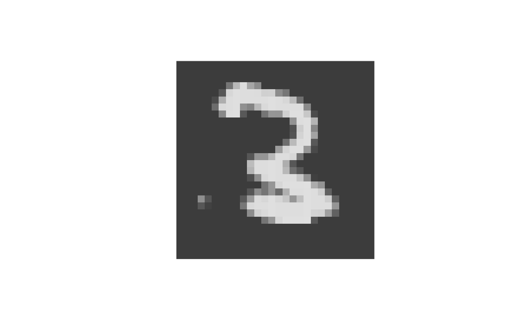

```r
mnist <- dataset_mnist()

digit <- mnist$train$x[50, 1:28, 1:28]
par(pty="s") # for keeping the aspect ratio 1:1
image(t(digit), col = gray.colors(256), axes = FALSE)
```

```r
x_train <- mnist$train$x
y_train <- mnist$train$y
x_test <- mnist$test$x
y_test <- mnist$test$y
dim(x_train)
```

```
## [1] 60000    28    28
```

```r
dim(x_test)
```

```
## [1] 10000    28    28
```

```r
# reshape
x_train <- array_reshape(x_train, c(nrow(x_train), 784))
x_test  <- array_reshape(x_test, c(nrow(x_test), 784))
```

Now we normalize the values, which are pixel intensities ranging in (0,255) and create the outcome.

```r
x_train <- x_train / 255
x_test <- x_test / 255
y_train <- to_categorical(y_train, 10)
y_test <- to_categorical(y_test, 10)
```

Now create the model in Keras.

```r
model <- keras_model_sequential()
model %>%
layer_dense(units = 256, activation = 'relu', input_shape = c(784)) %>%
layer_dropout(rate = 0.4) %>%
layer_dense(units = 128, activation = 'relu') %>%
layer_dropout(rate = 0.3) %>%
layer_dense(units = 10, activation = 'softmax')
summary(model)
```

```
## Model: "sequential_1"
## ________________________________________________________________________________
##  Layer (type)                       Output Shape                    Param #
## ================================================================================
##  dense_6 (Dense)                    (None, 256)                     200960
##  dropout_4 (Dropout)                (None, 256)                     0
##  dense_5 (Dense)                    (None, 128)                     32896
##  dropout_3 (Dropout)                (None, 128)                     0
##  dense_4 (Dense)                    (None, 10)                      1290
## ================================================================================
## Total params: 235146 (918.54 KB)
## Trainable params: 235146 (918.54 KB)
## Non-trainable params: 0 (0.00 Byte)
## ________________________________________________________________________________
```

```r
model %>% compile(
loss = 'categorical_crossentropy',
metrics = c('accuracy')
)
```

Now run the model to get a fitted deep learning network.

```r
history <- model %>% fit(
x_train, y_train,
epochs = 30, batch_size = 128,
validation_split = 0.2
)
```

```
## 375/375 - 1s - loss: 0.4374 - accuracy: 0.8675 - val_loss: 0.1614 - val_accuracy: 0.9543 - 1s/epoch - 3ms/step
## 375/375 - 1s - loss: 0.2023 - accuracy: 0.9398 - val_loss: 0.1210 - val_accuracy: 0.9647 - 774ms/epoch - 2ms/step
## 375/375 - 1s - loss: 0.1543 - accuracy: 0.9545 - val_loss: 0.1176 - val_accuracy: 0.9671 - 726ms/epoch - 2ms/step
## 375/375 - 1s - loss: 0.1285 - accuracy: 0.9622 - val_loss: 0.1056 - val_accuracy: 0.9701 - 752ms/epoch - 2ms/step
## 375/375 - 1s - loss: 0.1138 - accuracy: 0.9664 - val_loss: 0.0958 - val_accuracy: 0.9743 - 712ms/epoch - 2ms/step
## 375/375 - 1s - loss: 0.1043 - accuracy: 0.9694 - val_loss: 0.0939 - val_accuracy: 0.9747 - 709ms/epoch - 2ms/step
## 375/375 - 1s - loss: 0.0972 - accuracy: 0.9716 - val_loss: 0.0961 - val_accuracy: 0.9751 - 704ms/epoch - 2ms/step
## 375/375 - 1s - loss: 0.0906 - accuracy: 0.9733 - val_loss: 0.0885 - val_accuracy: 0.9776 - 779ms/epoch - 2ms/step
## 375/375 - 1s - loss: 0.0849 - accuracy: 0.9751 - val_loss: 0.0958 - val_accuracy: 0.9760 - 711ms/epoch - 2ms/step
## 375/375 - 1s - loss: 0.0800 - accuracy: 0.9765 - val_loss: 0.0968 - val_accuracy: 0.9785 - 739ms/epoch - 2ms/step
## 375/375 - 1s - loss: 0.0787 - accuracy: 0.9775 - val_loss: 0.0959 - val_accuracy: 0.9771 - 746ms/epoch - 2ms/step
## 375/375 - 1s - loss: 0.0739 - accuracy: 0.9789 - val_loss: 0.0996 - val_accuracy: 0.9784 - 730ms/epoch - 2ms/step
## 375/375 - 1s - loss: 0.0734 - accuracy: 0.9784 - val_loss: 0.0974 - val_accuracy: 0.9764 - 848ms/epoch - 2ms/step
## 375/375 - 1s - loss: 0.0685 - accuracy: 0.9804 - val_loss: 0.1007 - val_accuracy: 0.9782 - 852ms/epoch - 2ms/step
## 375/375 - 1s - loss: 0.0692 - accuracy: 0.9798 - val_loss: 0.0993 - val_accuracy: 0.9806 - 728ms/epoch - 2ms/step
## 375/375 - 1s - loss: 0.0654 - accuracy: 0.9819 - val_loss: 0.0965 - val_accuracy: 0.9809 - 756ms/epoch - 2ms/step
## 375/375 - 1s - loss: 0.0597 - accuracy: 0.9824 - val_loss: 0.1022 - val_accuracy: 0.9787 - 734ms/epoch - 2ms/step
## 375/375 - 1s - loss: 0.0616 - accuracy: 0.9831 - val_loss: 0.1089 - val_accuracy: 0.9778 - 703ms/epoch - 2ms/step
## 375/375 - 1s - loss: 0.0619 - accuracy: 0.9824 - val_loss: 0.1033 - val_accuracy: 0.9791 - 693ms/epoch - 2ms/step
## 375/375 - 1s - loss: 0.0562 - accuracy: 0.9838 - val_loss: 0.1119 - val_accuracy: 0.9801 - 684ms/epoch - 2ms/step
## 375/375 - 1s - loss: 0.0573 - accuracy: 0.9842 - val_loss: 0.1150 - val_accuracy: 0.9791 - 701ms/epoch - 2ms/step
## 375/375 - 1s - loss: 0.0556 - accuracy: 0.9839 - val_loss: 0.1156 - val_accuracy: 0.9787 - 696ms/epoch - 2ms/step
## 375/375 - 1s - loss: 0.0561 - accuracy: 0.9847 - val_loss: 0.1098 - val_accuracy: 0.9803 - 703ms/epoch - 2ms/step
## 375/375 - 1s - loss: 0.0551 - accuracy: 0.9840 - val_loss: 0.1099 - val_accuracy: 0.9799 - 670ms/epoch - 2ms/step
## 375/375 - 1s - loss: 0.0522 - accuracy: 0.9858 - val_loss: 0.1157 - val_accuracy: 0.9811 - 671ms/epoch - 2ms/step
## 375/375 - 1s - loss: 0.0515 - accuracy: 0.9848 - val_loss: 0.1271 - val_accuracy: 0.9797 - 751ms/epoch - 2ms/step
## 375/375 - 1s - loss: 0.0521 - accuracy: 0.9858 - val_loss: 0.1224 - val_accuracy: 0.9804 - 732ms/epoch - 2ms/step
## 375/375 - 1s - loss: 0.0517 - accuracy: 0.9860 - val_loss: 0.1283 - val_accuracy: 0.9791 - 698ms/epoch - 2ms/step
## 375/375 - 1s - loss: 0.0514 - accuracy: 0.9859 - val_loss: 0.1219 - val_accuracy: 0.9806 - 737ms/epoch - 2ms/step
## 375/375 - 1s - loss: 0.0486 - accuracy: 0.9868 - val_loss: 0.1339 - val_accuracy: 0.9783 - 759ms/epoch - 2ms/step
```

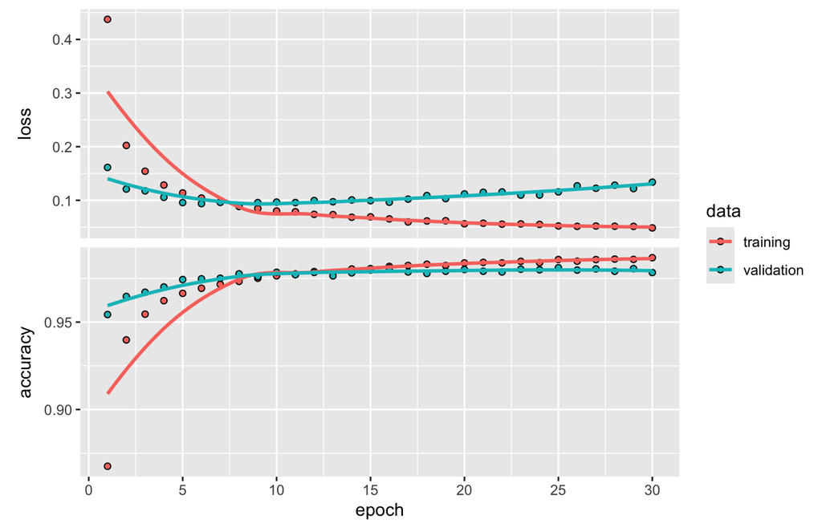

```r
plot(history)
```

```r
model %>% evaluate(x_test, y_test)
```

```
## 313/313 - 0s - loss: 0.1129 - accuracy: 0.9806 - 137ms/epoch - 437us/step
```

```
##      loss  accuracy
## 0.1129474 0.9806000
```

```r
model %>% predict(x_test) %>% k_argmax()
```

```
## 313/313 - 0s - 193ms/epoch - 617us/step
```

```
## tf.Tensor([7 2 1 ... 4 5 6], shape=(10000), dtype=int64)
```

The keras package also plots the progress of the model by showing the loss function evolution by epoch, as well as accuracy, for the training and validation samples.

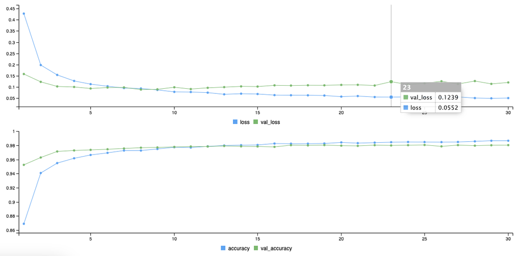

## `PyTorch`

Another popular way to fit NN’s is PyTorch. There is an R package `torch` that allows you to use PyTorch-like functionality natively from R. No Python installation is required: `torch` is built directly on top of libtorch, a C++ library that provides the tensor-computation and automatic-differentiation capabilities essential to building neural networks. See https://torch.mlverse.org/ for more information.

# Using `nnet` with Simulated Data

Now were going to do a Neural Net on some simulated data. We’re going to use the **nnet** package for the neural network:

Now we’ll simulate the data. Part of the difficulty in simulating multivariate normal data is getting a random positive definite matrix. The **clusterGeneration** package helps with this.

```r
#define number of variables and observations
set.seed(2)
num.vars<-8
num.obs<-10000

#define correlation matrix for explanatory variables
#define actual parameter values
cov.mat<-genPositiveDefMat(num.vars,covMethod=c("unifcorrmat"))$Sigma
rand.vars<-mvrnorm(num.obs,rep(0,num.vars),Sigma=cov.mat)
parms1<-runif(num.vars,-10,10)
y1<-rand.vars %*% matrix(parms1) + rnorm(num.obs,sd=20)
parms2<-runif(num.vars,-10,10)
y2<-rand.vars %*% matrix(parms2) + rnorm(num.obs,sd=20)

#prep data and create neural network
rand.vars<-data.frame(rand.vars)
resp<-apply(cbind(y1,y2),2, function(y) (y-min(y))/(max(y)-min(y)))
resp<-data.frame(resp)
names(resp)<-c('Y1','Y2')
```

This model has 8 variables with 2 outcomes and a total of 10,000 observations. We’ll fit this model with 8 hidden levels with the **nnet** function.

Some info about the **nnet** function:

- it is used for single-hidden layer networks only.
- The call is:

> nnet(x, y, weights, size, Wts, mask,linout = FALSE, entropy = FALSE, softmax = FALSE, censored = FALSE, skip = FALSE, rang = 0.7, decay = 0, maxit = 100, Hess = FALSE, trace = TRUE, MaxNWts = 1000, abstol = 1.0e-4, reltol = 1.0e-8, …)
- Some of the options (from the help file):

  – formula-A formula of the form class ~ x1 + x2 + …

  – x-matrix or data frame of x values for examples.

  – y-matrix or data frame of target values for examples.

  – weights-(case) weights for each example – if missing defaults to 1.

  – size-number of units in the hidden layer. Can be zero if there are skip-layer units.

  – Wts-initial parameter vector. If missing chosen at random.

  – linout-switch for linear output units. Default logistic output units.

  – entropy-switch for entropy (= maximum conditional likelihood) fitting. Default by least-squares.

  – softmax-switch for softmax (log-linear model) and maximum conditional likelihood fitting. linout, entropy, softmax and censored are mutually exclusive. censored A variant on softmax, in which non-zero targets mean possible classes. Thus for softmax a row of (0, 1, 1) means one example each of classes 2 and 3, but for censored it means one example whose class is only known to be 2 or 3.

  – rang-Initial random weights on [-rang, rang]. Value about 0.5 unless the inputs are large, in which case it should be chosen so that rang * max(|x|) is about 1.

  – decay-parameter for weight decay. Default 0.

  – maxit-maximum number of iterations. Default 100.

  – abstol-Stop if the fit criterion falls below abstol, indicating an essentially perfect fit.

  – reltol-Stop if the optimizer is unable to reduce the fit criterion by a factor of at least 1 - reltol.

```r
mod1<-nnet(rand.vars,resp,size=8,linout=T)
```

To plot the network we’re going to import a function from Github

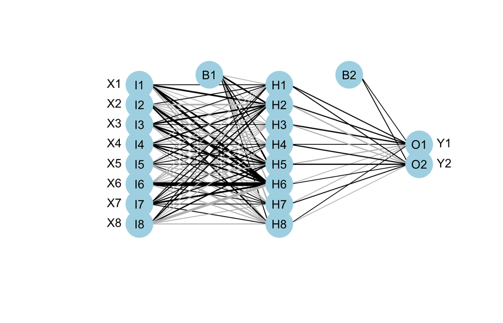

```r
source_url('https://gist.github.com/fawda123/7471137/raw/cd6e6a0b0bdb4e065c597e52165e5ac887f5fe95/nnet_plot_update.r')

plot.nnet(mod1)
```

Full url is ‘https://gist.github.com/fawda123/7471137/raw/cd6e6a0b0bdb4e065c597e52165e5ac887f5fe95/nnet_plot_update.r’

The shows all of the connections that fit. The black (gray) lines indicate a positive (negative) association. The thickness of the line indicates the strength of the association.

We can also visualize the effect that each variable has on the outcome using a method discribed in Gevrey et al. (2003) [1] (see below for reference). The hard thing about visualizing the effect one variable, say $X_1$, has on the outcome, say $Y$, is that all of the other variables, say $X_2, X_3,\ldots,X_r$ interact with this relationship. As a result, we visualize the effect between $X_1$ and $Y$ for fixed values of $X_2, X_3,\ldots,X_r$. One way to do this is to:

- Set $X_2, X_3,\ldots,X_r$ to a fixed quantile, for example $Q_1$, then feed all values of $X_1$ into the network and calculate the expected value of $Y$ for each value.
- Plot the expectation of $Y$ by $X_1$.
- Set $X_2, X_3,\ldots,X_r$ to a different fixed quantile, repeat as necessary.

This method will give you some idea of what is impacting the outcome, but it will not give any information on the interactions between the variables.

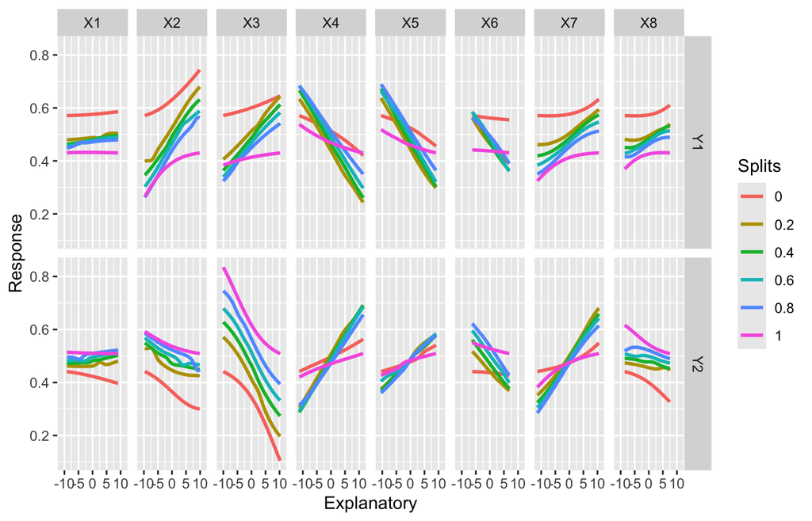

```r
source('https://gist.githubusercontent.com/fawda123/6860630/raw/b8bf4a6c88d6b392b1bfa6ef24759ae98f31877c/lek_fun.r')
lek.fun(mod1)
```

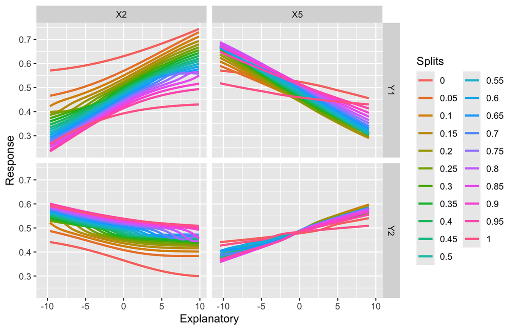

```r
lek.fun(mod1,var.sens=c('X2','X5'),split.vals=seq(0,1,by=0.05))
```

Full url is ‘https://gist.githubusercontent.com/fawda123/6860630/raw/b8bf4a6c88d6b392b1bfa6ef24759ae98f31877c/lek_fun.r’

Next we’re going to look at some measures of variable importance. The goal here is to measure the relative importance of explanatory variables for their relation to one or more response variables. The method we’ll use here is described in Garson (1991) [2]. Here is the basic idea:

- Identify all weighted connections between a specific input node and a specific response variable.
- Do this for all other explanatory variables until we have a list of all weights for each input variable.
- The connections are “tallied”” for each input node and scaled relative to all other inputs.
- A single value is obtained for each explanatory variable that describes the relationship with response variable in the model (see the appendix in Goh 1995 [3] for a more detailed description).

To do this we will import ‘gar.fun’ from Github (this is not a package just a function).

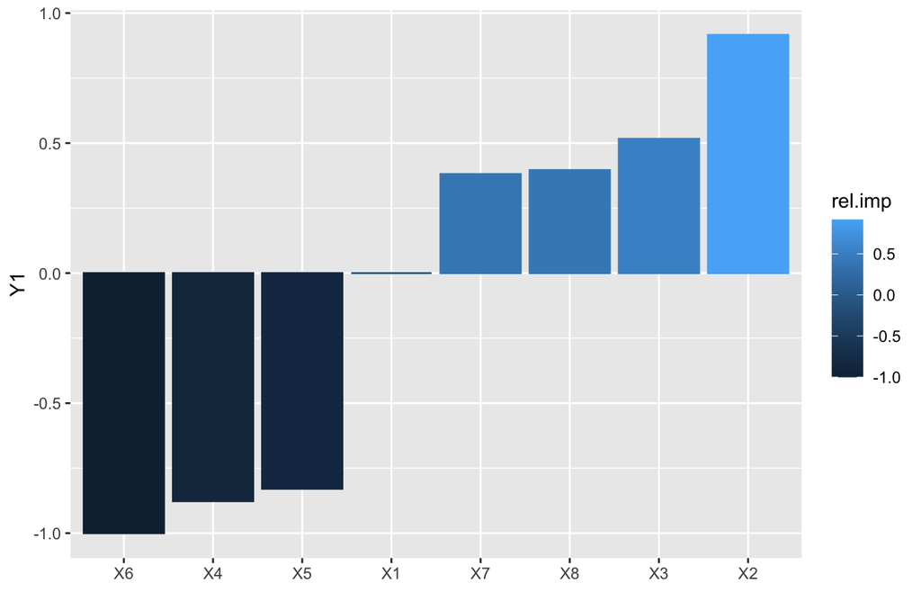

```r
source_url('https://gist.githubusercontent.com/fawda123/6206737/raw/d6f365c283a8cae23fb20892dc223bc5764d50c7/gar_fun.r')
#create a pretty color vector for the bar plot
cols<-colorRampPalette(c('lightgreen','lightblue'))(num.vars)

#use the function on the model created above
par(mar=c(3,4,1,1),family='serif')
gar.fun('Y1',mod1)
```

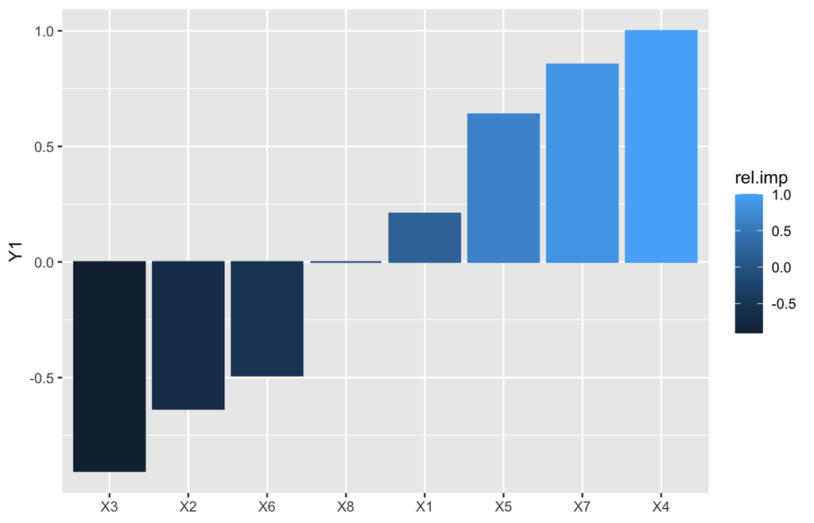

```r
gar.fun('Y2',mod1)
```

[1] Gevrey M, Dimopoulos I, Lek S. 2003. Review and comparison of methods to study the contribution of variables in artificial neural network models. Ecological Modelling. 160:249-264.

[2] Garson, G.D. 1991. Interpreting neural network connection weights. Artificial Intelligence Expert. 6(4):46–51.

[3] Goh, A.T.C. 1995. Back-propagation neural networks for modeling complex systems. Artificial Intelligence in Engineering. 9(3):143–151.